# Exercises: Dynamics

Berry Brosi

August 2024

# Preamble

These exercises can be run in either .Rmarkdown or .R. The key thing is to copy the code chunks (grey boxes with `monospaced font`) and paste them into your new file. If you’re used to working in .Rmarkdown, great! But that isn’t necessary.

**If you’re still new to R**, probably the easiest approach is:

- in RStudio, go to File > New File > R Script
- this will open a new window in your Rstudio environment, that expects only code (or comments prefaced with `#`)
- paste *only* the code from the code chunks (grey boxes with `monospaced font`)—don’t include any of the text from outside of the code chunks
- to run code line-by-line, highlight the code you want to run and then click on the “Run” button at the top right of the window with your code, and select “Run Selected Line(s)”
- alternatively, you can highlight the code and then use a keyboard shortcut:
  - Windows: control + Enter
  - Mac: command + return

As always, don’t be afraid to ask for help!

# Packages

Make sure to load this package!

```r
library(deSolve)
```

# Exercise 1: exponential growth

Here is code for modeling exponential growth using the `deSolve` package (more background on the workshop website). This code models a population over 100 time steps, with a starting population size of 12 and an $r$ of 0.2.

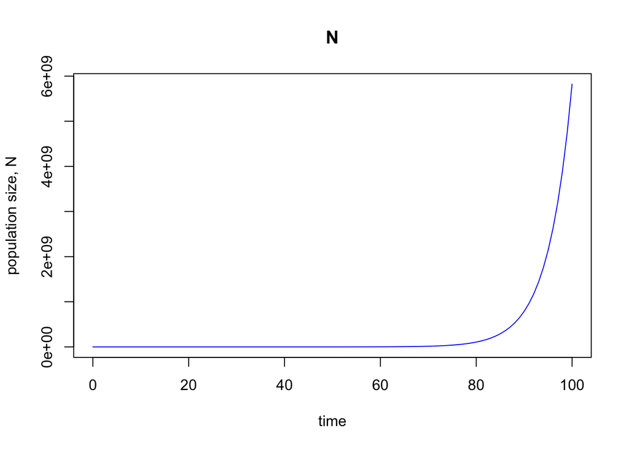

```r
# set initial conditions of response variable
popn <- c(N = 12)

# Parameters
parameters <- c(r = 0.2)

# Time sequence
times <- seq(0, 100, by = 1)

# "exp.model" stands for "exponential growth model"
exp.model <- function(time, popn, parameters) {
    # exponential growth model, dNdt = r*N:
    dNdt <- parameters['r'] * popn['N']
        # the function must return a list (even if it is just one element):
    return(list(dNdt))
  }

# Solve the ODE
out <- ode(y = popn, times = times, func = exp.model, parms = parameters)

# Plot the output
plot(out, ylab = "population size, N", col = "blue")
```

**TO-DO:** Copy the code above and then alter it to run a simulation of exponential growth over 200 time steps, for a population with an initial size of 202 individuals and $r$ = 0.225.

# Exercise 2: logistic growth

Below is example code for modeling logistic growth with `deSolve`, in a more compact form than for the exponential growth model above.

As our models become more complicated, it makes our life much easier to just include the name of the variables, e.g. `r` rather than `parameters['r']`. We can do that with the addition of just a single line of code, relative to the above:

`with(as.list(c(popn, params)), {...})`

*(see the workshop website for much more detail and motivation about how and why this works)*

Here is that code, and we’ll go ahead and plot the results:

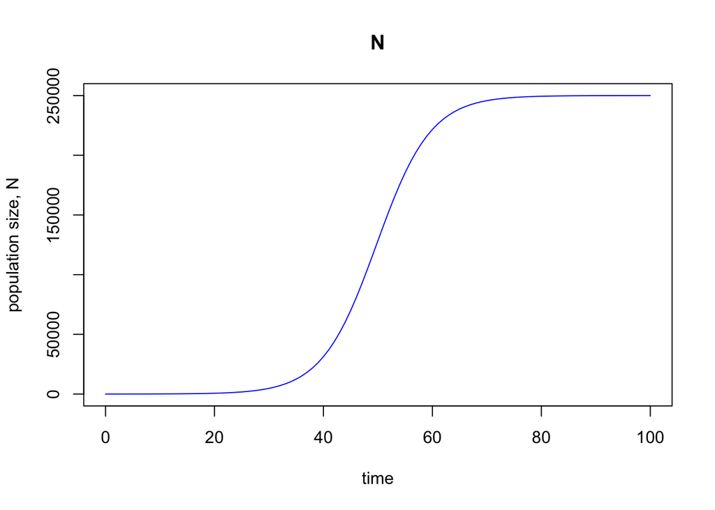

```r
# library(deSolve)

# set initial condition (at time zero) of our response variable
popn <- c(N = 12)

# Parameters
params <- c(r = 0.2,
            K = 250000)

# Time sequence
times <- seq(0, 100, by = 1)

# specify the model
logistic.model <- function(time, popn, parameters) {
    # `with` line tells code where to find the named elements in the model
    with(as.list(c(popn, params)), {
    # logistic growth equation--very transparent!:
    dNdt <- r*N*(1 - N/K)
    # again, for `ode` need to return a list, even if it's just a vector
    return(list(dNdt))
    })
  }

# Solve the ODE
out <- ode(y = popn,
           times = times,
           func = logistic.model,
           parms = params)

# Plot the output
plot(out,
     ylab = "population size, N",
     col = "blue")
```

**TO-DO:** Run the logistic growth code above, and then *re-run* it, altering the code to have a much larger value of $r$ of your choice, but less than $r = 2$ (keep $K$ the same). Re-name the variable `out` when you re-run it—call it `out2` so you have access to the data from both runs.

To alter the code to run it for a second population, perhaps the simplest thing would be to copy and then paste the whole code chunk *twice*, the second time altering the value of $r$ and changing the name of `out` to `out2`. If you’re relatively new to R or coding, you may wish to take that approach.

But really you are just changing the one parameter ($r$) and then re-solving the same equation, so you don’t have to paste everything again. To paste (much) less, you could paste *only* the line specifying the parameters (starting with `params <-`) and then the code that solves the ode (starting with `out <-`); again, you will want to change `out` to `out2`.

Plot both curves on the same graph, with two different colors. Here is how to do the plotting:

```r
# Plot the output of two different populations
plot(out,
     ylab = "population size, N",
     col = "blue")
lines(out2, col = "red")
```

you should get something back that looks a little something like this, but your exact red line will vary depending on the value of $r$ you chose:

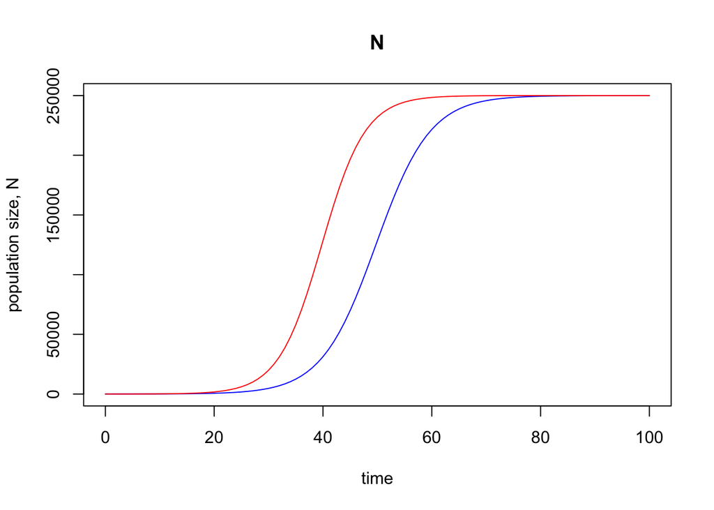